# Régime alimentaire du chamois : secteurs et structure spatiale

Dryas Statistics

16/10/2026

```r
# À exécuter une seule fois sur chaque ordinateur si nécessaire :
install.packages(c("rmarkdown", "knitr", "dplyr", "tidyr", "ggplot2", "ggrepel",
                   "sf", "vegan", "cluster"))

# Depuis la racine du projet :
rmarkdown::render("Script/Analyse_regimes_chamois_secteurs.Rmd")

# Ou depuis le dossier Script :
rmarkdown::render("Analyse_regimes_chamois_secteurs.Rmd")
```

# 1 Préparation et contrôles des données

## 1.1 Import du fichier de régimes

```r
diet <- read_rdata_object(resolve_input(params$diet_file), "diet_long_chamois")
needed <- c("N_Antagene", "species", "occurrences", "Date", "Latitude",
            "Longitude", "Circuitcomptage")
if (!all(needed %in% names(diet)))
  stop("Colonnes manquantes : ", paste(setdiff(needed, names(diet)), collapse = ", "))
diet$N_Antagene <- as.character(diet$N_Antagene)
diet$species <- as.character(diet$species)
if (!is.numeric(diet$occurrences)) stop("occurrences doit être numérique.")
if (anyNA(diet[c("N_Antagene", "species", "occurrences")]))
  stop("Identifiant, taxon ou valeur d'occurrences manquants.")
if (any(!nzchar(diet$N_Antagene)) || any(!nzchar(diet$species)))
  stop("Identifiant ou taxon vide.")
if (any(!is.finite(diet$occurrences)) || any(diet$occurrences < 0))
  stop("Les occurrences doivent être finies et positives ou nulles.")
if (anyDuplicated(diet[c("N_Antagene", "species")]))
  stop("Plusieurs lignes pour un même couple fèces × taxon : vérifier avant analyse.")
meta <- diet %>% select(-species, -occurrences) %>% distinct()
if (anyDuplicated(meta$N_Antagene))
  stop("Des métadonnées contradictoires existent pour une même fèces.")
meta$date_originale <- parse_date(meta$Date)
meta$secteur_original <- as.character(meta$Circuitcomptage)
meta$id_jointure <- normalize_id(meta$N_Antagene)

wide <- diet %>% select(N_Antagene, species, occurrences) %>%
  pivot_wider(names_from = species, values_from = occurrences, values_fill = 0)
Y <- as.matrix(as.data.frame(wide[, setdiff(names(wide), "N_Antagene"), drop = FALSE]))
rownames(Y) <- wide$N_Antagene
storage.mode(Y) <- "double"
# Tri fixe pour rendre les procédures sensibles aux égalités reproductibles.
Y <- Y[order(rownames(Y)), order(colnames(Y)), drop = FALSE]
meta <- as.data.frame(meta[match(rownames(Y), meta$N_Antagene), ])
stopifnot(identical(meta$N_Antagene, rownames(Y)))
```

## 1.2 Appariement au fichier cartographique

Seuls les identifiants présents dans le fichier de régimes sont analysés. Le GPKG sert à compléter les **dates et secteurs manquants**, et à fournir les coordonnées pour l’exploration spatiale. Les valeurs déjà renseignées de date et de secteur ne sont pas remplacées. Les secteurs du fichier de régimes restent donc prioritaires, après harmonisation des variantes explicites.

L’appariement est exact sur la partie numérique de l’identifiant : par exemple, `E00944149` correspond à `944 149`. Une correspondance n’est pas une validation sur le terrain des coordonnées.

```r
gpkg <- sf::st_read(resolve_input(params$gpkg_file, paths$spatial_dir),
                     layer = params$gpkg_layer, quiet = TRUE)
if (is.na(sf::st_crs(gpkg))) stop("Le GPKG n'a pas de système de coordonnées.")
# Les lecteurs GDAL/sf peuvent transformer "Circuit co" en "Circuit.co"
# ou "Circuit_co". On compare des noms sans accents ni ponctuation, tout en
# conservant les noms réels pour extraire les colonnes.
column_key <- function(x) {
  z <- iconv(enc2utf8(x), from = "UTF-8", to = "ASCII//TRANSLIT", sub = "")
  gsub("[^a-z0-9]", "", tolower(z))
}
resolve_gpkg_column <- function(candidates, explicit = NULL, required = TRUE, role) {
  available <- names(sf::st_drop_geometry(gpkg))
  if (!is.null(explicit) && length(explicit) == 1L && nzchar(explicit)) {
    if (!explicit %in% available)
      stop("Colonne GPKG demandée pour ", role, " : '", explicit,
           "', absente. Colonnes disponibles : ", paste(available, collapse = ", "))
    return(explicit)
  }
  keys <- column_key(available)
  for (candidate in candidates) {
    hit <- available[keys == column_key(candidate)]
    if (length(hit) > 1L)
      stop("Plusieurs colonnes possibles pour ", role, " : ",
           paste(hit, collapse = ", "),
           ". Renseigner gpkg_id_col, gpkg_sector_col ou gpkg_date_col dans le YAML.")
    if (length(hit) == 1L) return(hit)
  }
  if (required)
    stop("Colonne d'identifiant introuvable dans la couche '", params$gpkg_layer,
         "'. Colonnes disponibles : ", paste(available, collapse = ", "),
         ". Renseigner gpkg_id_col dans le YAML avec le nom exact de l'identifiant des prélèvements.")
  warning("Colonne non reconnue pour ", role,
          " : les valeurs correspondantes du GPKG ne compléteront pas les métadonnées.",
          " Colonnes disponibles : ", paste(available, collapse = ", "))
  NULL
}
id_col <- resolve_gpkg_column(
  c("Identifica", "Identification", "Identifiant", "N_Antagene", "Code_Antagene"),
  explicit = params$gpkg_id_col, role = "l'identifiant")
sector_col <- resolve_gpkg_column(
  c("Circuit co", "Circuit comptage", "Circuitcomptage", "Circuit", "Secteur"),
  explicit = params$gpkg_sector_col, required = FALSE, role = "le secteur")
date_col <- resolve_gpkg_column(
  c("Date", "Date prelevement", "Date collecte", "Date echantillon"),
  explicit = params$gpkg_date_col, required = FALSE, role = "la date")
colonnes_gpkg <- data.frame(
  role = c("Identifiant", "Secteur", "Date"),
  colonne = c(id_col, if (is.null(sector_col)) "Non reconnue" else sector_col,
               if (is.null(date_col)) "Non reconnue" else date_col))
tab(colonnes_gpkg)
```

| role | colonne |
| --- | --- |
| Identifiant | Identifica |
| Secteur | Circuit.co |
| Date | Date |

```r
export_csv(colonnes_gpkg, "correspondance_colonnes_gpkg.csv")
gpkg$id_jointure <- normalize_id(gpkg[[id_col]])
if (!any(!is.na(gpkg$id_jointure) & gpkg$id_jointure %in% meta$id_jointure))
  stop("Aucun identifiant du GPKG ne correspond aux données de régime. Colonne utilisée : ",
       id_col, ". Exemples GPKG : ", paste(head(gpkg[[id_col]], 5), collapse = ", "),
       "; exemples régime : ", paste(head(meta$N_Antagene, 5), collapse = ", "))
gpkg <- gpkg[!is.na(gpkg$id_jointure) & gpkg$id_jointure %in% meta$id_jointure, ]
if (anyDuplicated(gpkg$id_jointure))
  stop("Plusieurs positions GPKG pour un même identifiant : résoudre l'ambiguïté.")
if (any(sf::st_is_empty(gpkg))) stop("Géométrie vide parmi les points appariés.")
if (any(as.character(sf::st_geometry_type(gpkg)) != "POINT"))
  stop("Des géométries appariées ne sont pas des points.")
gpkg <- sf::st_transform(gpkg, 2154)
xy <- sf::st_coordinates(gpkg)
ll <- sf::st_coordinates(sf::st_transform(gpkg, 4326))
g <- data.frame(id_jointure = gpkg$id_jointure,
                secteur_gpkg = if (is.null(sector_col)) rep(NA_character_, nrow(gpkg)) else
                  as.character(gpkg[[sector_col]]),
                date_gpkg = if (is.null(date_col)) rep(as.Date(NA), nrow(gpkg)) else
                  parse_date(gpkg[[date_col]]),
                est = xy[, 1], nord = xy[, 2],
                longitude_gpkg = ll[, 1], latitude_gpkg = ll[, 2])
meta <- meta %>% left_join(g, by = "id_jointure") %>% as.data.frame()
meta$secteur <- normalize_sector(dplyr::coalesce(meta$secteur_original, meta$secteur_gpkg))
meta$date <- dplyr::coalesce(meta$date_originale, meta$date_gpkg)
meta$mois <- as.integer(format(meta$date, "%m"))
meta$date_completee <- is.na(meta$date_originale) & !is.na(meta$date_gpkg)
meta$secteur_complete <- is.na(normalize_sector(meta$secteur_original)) & !is.na(meta$secteur)
# Traiter aussi les champs de secteur vides plutôt que NA, le cas échéant.
ii_blank <- is.na(normalize_sector(meta$secteur_original))
meta$secteur[ii_blank] <- normalize_sector(meta$secteur_gpkg[ii_blank])
meta$secteur_complete <- ii_blank & !is.na(meta$secteur)
meta$signal_total <- rowSums(Y)
meta$coord_appariees <- is.finite(meta$est) & is.finite(meta$nord)
stopifnot(identical(meta$N_Antagene, rownames(Y)))

completions <- meta %>% filter(date_completee | secteur_complete) %>%
  select(N_Antagene, secteur_original, secteur_gpkg, secteur,
         date_originale, date_gpkg, date)
tab(completions)
```

| N_Antagene | secteur_original | secteur_gpkg | secteur | date_originale | date_gpkg | date |
| --- | --- | --- | --- | --- | --- | --- |
| E00963478 | NA | Plain des bœufs | Plain des bœufs | NA | 2025-08-19 | 2025-08-19 |
| E00963490 | NA | Goulot du Loup | Goulot du Loup | NA | 2025-07-23 | 2025-07-23 |

```r
export_csv(completions, "metadonnees_completees.csv")

# Écart entre coordonnées originales et GPKG, sans modifier les sources.
meta$ecart_coord_m <- NA_real_
valid_raw <- is.finite(meta$Latitude) & is.finite(meta$Longitude) &
  abs(meta$Latitude) <= 90 & abs(meta$Longitude) <= 180 & meta$coord_appariees
if (any(valid_raw)) {
  raw_points <- sf::st_as_sf(meta[valid_raw, ], coords = c("Longitude", "Latitude"), crs = 4326)
  raw_xy <- sf::st_coordinates(sf::st_transform(raw_points, 2154))
  meta$ecart_coord_m[valid_raw] <- sqrt(rowSums(
    (raw_xy - as.matrix(meta[valid_raw, c("est", "nord")]))^2))
}
coord_alertes <- meta %>% filter(!is.na(ecart_coord_m), ecart_coord_m > 20) %>%
  select(N_Antagene, secteur, Latitude, Longitude,
         latitude_gpkg, longitude_gpkg, ecart_coord_m)
tab(coord_alertes, digits = 5)
```

| N_Antagene | secteur | Latitude | Longitude | latitude_gpkg | longitude_gpkg | ecart_coord_m |
| --- | --- | --- | --- | --- | --- | --- |
| E00944152 | Hohneck | 40.04200 | 7.01000 | 48.04200 | 7.01000 | 889569.19158 |
| E00944154 | Hohneck | 40.04500 | 7.01200 | 48.04500 | 7.01200 | 889567.72605 |
| E00963471 | Goutte des saules | 47.78835 | 6.76501 | 47.78834 | 6.76658 | 117.40621 |
| E00963474 | Goutte des saules | 47.78835 | 6.76501 | 47.78849 | 6.76671 | 128.58246 |
| E00963484 | Goutte des saules | 47.78838 | 6.76576 | 47.78813 | 6.76591 | 30.04356 |
| E00963487 | Plancher-les-Mines | 47.78639 | 6.75336 | 47.78632 | 6.75306 | 23.65974 |
| E00963493 | Goulot du Loup | 47.79990 | 6.77763 | 47.79869 | 6.78179 | 339.37978 |
| E00963495 | Goulot du Loup | 47.79953 | 6.77668 | 47.79984 | 6.78305 | 478.13207 |
| E00963496 | Plain des bœufs | 47.79964 | 6.77677 | 47.79989 | 6.78321 | 482.91945 |
| E00963498 | Goulot du Loup | 47.80083 | 6.77648 | 47.80076 | 6.78051 | 302.22572 |
| E00963501 | Goulot du Loup | 47.79961 | 6.77651 | 47.80000 | 6.78305 | 491.69174 |
| E00963509 | Goulot du Loup | 47.79953 | 6.77668 | 47.79986 | 6.78312 | 484.04311 |
| E00963511 | Goulot du Loup | 47.79953 | 6.77668 | 47.79979 | 6.78293 | 469.02521 |
| E00963512 | Goulot du Loup | 47.79964 | 6.77652 | 47.79992 | 6.78280 | 471.45917 |
| E00963678 | Plancher-les-Mines | 47.78639 | 6.75336 | 47.78624 | 6.75307 | 26.87502 |
| E00963680 | Plancher-les-Mines | 47.78639 | 6.75336 | 47.78628 | 6.75312 | 21.23425 |
| E00982258 | Morteville | 47.81944 | 6.94450 | 47.81944 | 6.84450 | 7483.36666 |

```r
export_csv(coord_alertes, "ecarts_coordonnees_superieurs_20m.csv")
```

## 1.3 Exclusions, normalisation et effectifs

Une fèces sans aucun signal végétal est exclue de la comparaison des régimes ; elle n’est pas interprétée comme un régime vide. Chaque profil est divisé par son signal total afin de donner le même poids à chaque fèces, indépendamment du nombre de séquences. Les pourcentages obtenus **ne sont pas des pourcentages de biomasse consommée** et ne permettent pas d’inférer une sélection des plantes. Les catégories taxonomiques sont conservées telles que fournies.

```r
controle_complet <- meta
sans_signal <- meta %>% filter(signal_total <= 0)
keep <- meta$signal_total > 0
meta <- meta[keep, , drop = FALSE]
Y <- Y[keep, , drop = FALSE]
P <- sweep(Y, 1, rowSums(Y), "/")
stopifnot(all(is.finite(P)), max(abs(rowSums(P) - 1)) < 1e-10,
          identical(meta$N_Antagene, rownames(P)))
D <- as.matrix(vegan::vegdist(P, method = "bray"))
effectifs <- meta %>% filter(!is.na(secteur)) %>% count(secteur, name = "n") %>%
  arrange(desc(n), secteur)
secteurs_principaux <- effectifs$secteur[effectifs$n >= params$min_n_sector]
if (length(secteurs_principaux) < 2) stop("Moins de deux secteurs suffisamment échantillonnés.")
main <- !is.na(meta$secteur) & meta$secteur %in% secteurs_principaux & !is.na(meta$mois)
tous <- !is.na(meta$secteur) & !is.na(meta$mois)
spatial <- meta$coord_appariees & !is.na(meta$mois)

bilan <- data.frame(
  Etape = c("Fèces dans le fichier initial", "Sans signal végétal (exclues)",
            "Fèces avec signal végétal", "Avec secteur et mois renseignés",
            "Analyse principale : secteurs suffisamment échantillonnés",
            "Analyse spatiale : coordonnées appariées et mois renseigné"),
  n = c(nrow(controle_complet), nrow(sans_signal), nrow(meta), sum(tous), sum(main), sum(spatial)))
tab(bilan)
```

| Etape | n |
| --- | --- |
| Fèces dans le fichier initial | 165 |
| Sans signal végétal (exclues) | 11 |
| Fèces avec signal végétal | 154 |
| Avec secteur et mois renseignés | 153 |
| Analyse principale : secteurs suffisamment échantillonnés | 147 |
| Analyse spatiale : coordonnées appariées et mois renseigné | 115 |

```r
tab(effectifs)
```

| secteur | n |
| --- | --- |
| Hohneck | 31 |
| Plain des bœufs | 24 |
| Plain des joncs | 24 |
| Ballon de Servance | 15 |
| Morteville | 15 |
| Étang des Roseaux | 14 |
| Goulot du Loup | 7 |
| Plancher-les-Mines | 6 |
| Rouge Gazon (neuf bois) | 6 |
| Goutte des Saules | 5 |
| Goutte des saules | 3 |
| Plain-des-boeufs | 2 |
| Bois Malvaux | 1 |

```r
tab(as.data.frame.matrix(table(meta$secteur[main], meta$mois[main])), row.names = TRUE)
```

|  | 7 | 8 | 9 | 10 |
| --- | --- | --- | --- | --- |
| Ballon de Servance | 5 | 5 | 0 | 5 |
| Étang des Roseaux | 0 | 0 | 10 | 4 |
| Goulot du Loup | 5 | 2 | 0 | 0 |
| Goutte des Saules | 0 | 0 | 5 | 0 |
| Hohneck | 7 | 5 | 3 | 16 |
| Morteville | 5 | 4 | 1 | 5 |
| Plain des bœufs | 5 | 7 | 3 | 9 |
| Plain des joncs | 9 | 12 | 0 | 3 |
| Plancher-les-Mines | 0 | 0 | 2 | 4 |
| Rouge Gazon (neuf bois) | 2 | 2 | 0 | 2 |

```r
if (nrow(sans_signal)) tab(sans_signal %>% select(N_Antagene, secteur, date))
```

| N_Antagene | secteur | date |
| --- | --- | --- |
| E00944163 | NA | 2025-09-02 |
| E00944202 | Hohneck | 2025-10-09 |
| E00963497 | Plain des bœufs | 2025-08-19 |
| E00963498 | Goulot du Loup | 2025-07-24 |
| E00963508 | Plain des bœufs | 2025-07-10 |
| E00963751 | Ballon de Servance | 2025-07-09 |
| E00963841 | Plain des joncs | 2025-10-21 |
| E00963843 | Plain des joncs | 2025-07-23 |
| E00982461 | Plancher-les-Mines | 2025-09-24 |
| E00982480 | Plain des joncs | 2025-08-05 |
| E00982491 | Plain des joncs | 2025-07-16 |

```r
export_csv(bilan, "bilan_effectifs.csv")
export_csv(effectifs, "effectifs_par_secteur.csv")
export_csv(controle_complet, "controle_tous_les_echantillons.csv")
export_csv(sans_signal, "echantillons_sans_signal.csv")
```

Avec les fichiers initiaux, on attend 115 fèces, dont 6 sans signal végétal, 109 profils exploitables, 108 avec un secteur, 95 dans les six secteurs principaux et 86 appariés au GPKG. Ces valeurs servent de repère et ne bloquent pas le rapport si les données sont actualisées.

# 2 Fonctions d’analyse

Les fonctions ci-dessous explicitent les calculs utilisés lors de l’exploration initiale. La PERMANOVA utilise le même principe géométrique que `adonis2` : inerties calculées à partir de la matrice de distances centrée. Ici, on teste **l’ajout du secteur après le mois**, puis on permute les étiquettes de secteur au sein du mois. Cela conserve la répartition mensuelle des effectifs par secteur.

```r
center_distance <- function(d) {
  a <- -0.5 * as.matrix(d)^2
  a <- sweep(a, 1, rowMeans(a), "-")
  sweep(a, 2, colMeans(a), "-")
}
# center_distance soustrait les moyennes successivement ; le résultat équivaut à JAJ.
dummy <- function(x) {
  x <- as.character(x)
  lev <- sort(unique(x))
  if (length(lev) <= 1L) return(matrix(numeric(0), nrow = length(x), ncol = 0))
  out <- outer(x, lev[-1], FUN = "==") * 1
  colnames(out) <- lev[-1]
  out
}
perm_index <- function(blocks) {
  out <- seq_along(blocks)
  for (b in split(seq_along(blocks), as.character(blocks)))
    out[b] <- b[sample.int(length(b))]
  out
}
qr_basis <- function(X) {
  q <- qr(X)
  qr.Q(q)[, seq_len(q$rank), drop = FALSE]
}
permanova_conditionnelle <- function(d, secteur, mois, nperm = params$nperm) {
  d <- as.matrix(d)
  secteur <- as.character(secteur)
  mois <- as.character(mois)
  n <- nrow(d)
  if (anyNA(secteur) || anyNA(mois) || length(secteur) != n || length(mois) != n)
    stop("Métadonnées absentes ou mal alignées pour la PERMANOVA.")
  G <- center_distance(d)
  X0 <- cbind(Intercept = 1, dummy(mois))
  Q0 <- qr_basis(X0)
  r0 <- ncol(Q0)
  ss0 <- sum(Q0 * (G %*% Q0))
  total <- sum(diag(G))
  stat <- function(s) {
    X <- cbind(X0, dummy(s))
    Q <- qr_basis(X)
    r <- ncol(Q)
    if (r <= r0 || n <= r) return(c(F = NA_real_, R2 = NA_real_))
    ss <- sum(Q * (G %*% Q))
    ajout <- ss - ss0
    resid <- total - ss
    c(F = (ajout / (r - r0)) / (resid / (n - r)), R2 = ajout / total)
  }
  observed <- stat(secteur)
  if (!is.finite(observed["F"])) stop("Effet secteur non estimable après le mois.")
  ge <- 0L
  for (i in seq_len(nperm)) {
    z <- stat(secteur[perm_index(mois)])
    if (!is.finite(z["F"])) stop("Permutation non estimable : revoir les blocs.")
    ge <- ge + (z["F"] >= observed["F"] - 1e-12)
  }
  data.frame(n = n, pseudo_F = unname(observed["F"]),
             R2_ajoute = unname(observed["R2"]), p = (ge + 1) / (nperm + 1),
             permutations = nperm)
}
aggregate_sector_month <- function(p, md) {
  stopifnot(nrow(p) == nrow(md))
  if (anyNA(md$secteur) || anyNA(md$mois)) stop("Secteur/mois manquant avant agrégation.")
  blocks <- split(seq_len(nrow(md)), interaction(md$secteur, md$mois, drop = TRUE))
  meanmat <- do.call(rbind, lapply(blocks, function(ii) colMeans(p[ii, , drop = FALSE])))
  mdmean <- do.call(rbind, lapply(blocks, function(ii) {
    data.frame(secteur = md$secteur[ii[1]], mois = md$mois[ii[1]],
               n_feces = length(ii),
               est = if (all(is.finite(md$est[ii]))) median(md$est[ii]) else NA_real_,
               nord = if (all(is.finite(md$nord[ii]))) median(md$nord[ii]) else NA_real_)
  }))
  rownames(mdmean) <- rownames(meanmat)
  list(P = meanmat, meta = mdmean)
}
# Dispersion sur l'espace euclidien de sqrt(Bray-Curtis), distances au centroïde,
# correction sqrt(n/(n-1)), puis test F ajoutant le secteur après le mois.
# Permutation des résidus du modèle réduit au sein du mois (Freedman-Lane).
dispersion_conditionnelle <- function(d, secteur, mois, nperm = params$nperm) {
  G <- center_distance(sqrt(as.matrix(d)))
  eg <- eigen(G, symmetric = TRUE)
  positive <- eg$values > 1e-10
  if (!any(positive)) stop("Axe positif absent pour la dispersion.")
  coords <- sweep(eg$vectors[, positive, drop = FALSE], 2,
                  sqrt(eg$values[positive]), "*")
  distances <- numeric(length(secteur))
  for (ii in split(seq_along(secteur), as.character(secteur))) {
    if (length(ii) < 2) stop("Au moins 2 fèces par secteur pour la dispersion.")
    centered <- sweep(coords[ii, , drop = FALSE], 2,
                       colMeans(coords[ii, , drop = FALSE]), "-")
    distances[ii] <- sqrt(rowSums(centered^2)) * sqrt(length(ii)/(length(ii)-1))
  }
  X0 <- cbind(1, dummy(mois)); Q0 <- qr_basis(X0)
  X1 <- cbind(X0, dummy(secteur)); Q1 <- qr_basis(X1)
  H0 <- tcrossprod(Q0); H1 <- tcrossprod(Q1)
  n <- length(distances); r0 <- ncol(Q0); r1 <- ncol(Q1)
  if (n <= r1 || r1 <= r0) stop("Modèle de dispersion non estimable.")
  statistic <- function(y) {
    as.numeric((crossprod(y, (H1-H0) %*% y)/(r1-r0)) /
                 (crossprod(y, (diag(n)-H1) %*% y)/(n-r1)))
  }
  observed <- statistic(distances)
  fitted <- as.numeric(H0 %*% distances)
  resid <- distances - fitted
  ge <- 0L
  for (i in seq_len(nperm))
    ge <- ge + (statistic(fitted + resid[perm_index(mois)]) >= observed - 1e-12)
  list(test = data.frame(F = observed, p = (ge+1)/(nperm+1), permutations = nperm),
       distances = data.frame(secteur = secteur, mois = mois, distance = distances))
}
# Indice de Rand ajusté sans dépendance supplémentaire.
adjusted_rand <- function(a, b) {
  tb <- table(a, b)
  c2 <- function(z) sum(z * (z-1)/2)
  total <- length(a) * (length(a)-1)/2
  if (total == 0) return(1)
  obs <- c2(tb); ra <- c2(rowSums(tb)); cb <- c2(colSums(tb))
  expected <- ra*cb/total
  denominator <- (ra+cb)/2 - expected
  if (abs(denominator) < 1e-14) return(ifelse(abs(obs-expected) < 1e-14, 1, 0))
  (obs-expected)/denominator
}
# Moran multivarié sur les résidus des profils Hellinger ajustés au mois.
# Graphe binaire k-NN symétrisé ; tous les ex aequo sont conservés.
spatial_moran <- function(p, xy, mois, k = 5, nperm = params$nperm) {
  stopifnot(nrow(p) == nrow(xy), nrow(p) == length(mois), all(is.finite(xy)))
  if (nrow(p) <= k) stop("Pas assez de positions pour le nombre de voisins demandé.")
  dd <- as.matrix(dist(xy)); diag(dd) <- Inf
  threshold <- apply(dd, 1, function(z) sort(z, partial = k)[k])
  W <- (sweep(dd, 1, threshold + 1e-8, "<=") * 1)
  W <- pmax(W, t(W)); diag(W) <- 0
  h <- sqrt(p)
  X <- cbind(1, dummy(mois)); Q <- qr_basis(X)
  R <- h - Q %*% crossprod(Q, h)
  S <- tcrossprod(R)
  denominator <- sum(diag(S))
  if (denominator <= 1e-14 || sum(W) == 0) stop("Signal résiduel ou graphe spatial vide.")
  scale <- nrow(R)/sum(W)
  observed <- scale*sum(W*S)/denominator
  ge <- 0L
  for (i in seq_len(nperm)) {
    pp <- perm_index(mois)
    z <- scale*sum(W*S[pp, pp, drop = FALSE])/denominator
    ge <- ge + (z >= observed - 1e-12)
  }
  data.frame(n = nrow(p), voisins = k, I = observed,
             p = (ge+1)/(nperm+1), permutations = nperm)
}
```

# 3 Comparaison des secteurs

## 3.1 Composition moyenne

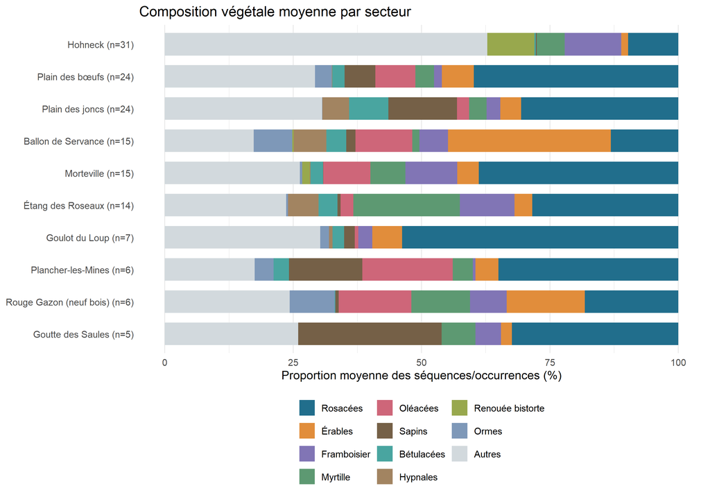

```r
plant_names <- c(Rosaceae = "Rosacées", Acer = "Érables", Rubusidaeus = "Framboisier",
                  Vacciniummyrtillus = "Myrtille", Oleaceae = "Oléacées",
                  Betulaceae = "Bétulacées", Bistortaofficinalis = "Renouée bistorte",
                  Ceratodonpurpureus = "Ceratodon (mousse)",
                  Filipendulaulmaria = "Reine-des-prés", Ulmus = "Ormes", Abies = "Sapins")
label_taxon <- function(z) {
  y <- unname(plant_names[z]); y[is.na(y)] <- z[is.na(y)]; y
}
mean_sect <- do.call(rbind, lapply(secteurs_principaux, function(s)
  colMeans(P[meta$secteur %in% s, , drop = FALSE])))
rownames(mean_sect) <- secteurs_principaux
top10 <- names(sort(colMeans(P[main, , drop = FALSE]), decreasing = TRUE))[seq_len(min(10, ncol(P)))]
comp <- as.data.frame(mean_sect[, top10, drop = FALSE], check.names = FALSE)
comp$Autres <- pmax(0, 1-rowSums(comp))
comp$secteur <- rownames(comp)
comp <- comp %>% pivot_longer(-secteur, names_to = "taxon", values_to = "proportion")
comp$taxon <- factor(comp$taxon, levels = c(top10, "Autres"),
                      labels = label_taxon(c(top10, "Autres")))
comp$secteur <- factor(comp$secteur, levels = rev(secteurs_principaux))
labels_sector <- setNames(paste0(effectifs$secteur, " (n=", effectifs$n, ")"), effectifs$secteur)
p_comp <- ggplot(comp, aes(x = secteur, y = 100*proportion, fill = taxon)) +
  geom_col(width = .7) + coord_flip() +
  scale_x_discrete(labels = labels_sector) +
  scale_fill_manual(values = c("#216e8c", "#e18d3b", "#8175b5", "#5d9972", "#ce6679",
                                "#756047", "#49a5a0", "#a28461", "#98a84d", "#7e98b8", "#d2d9dd")) +
  labs(x = NULL, y = "Proportion moyenne des séquences/occurrences (%)", fill = NULL,
       title = "Composition végétale moyenne par secteur") +
  theme(legend.position = "bottom", panel.grid.major.y = element_blank()) +
  guides(fill = guide_legend(ncol = 3))
p_comp
```

```r
save_plot(p_comp, "composition_par_secteur.png", height = 7)
export_csv(comp, "composition_taxons_principaux.csv")
```

Les proportions décrivent les séquences/occurrences végétales identifiées, avec un poids égal par fèces. Elles ne mesurent pas directement les quantités consommées. Les moyennes descriptives du graphique ne sont pas ajustées sur le mois ; le test ci-dessous l’est.

## 3.2 PERMANOVA globale et sensibilités

```r
set.seed(params$seed + 10L)
main_test <- permanova_conditionnelle(D[main, main, drop = FALSE],
                                      meta$secteur[main], meta$mois[main])
all_test <- permanova_conditionnelle(D[tous, tous, drop = FALSE],
                                     meta$secteur[tous], meta$mois[tous])
agg_main <- aggregate_sector_month(P[main, , drop = FALSE], meta[main, , drop = FALSE])
agg_test <- permanova_conditionnelle(vegan::vegdist(agg_main$P, "bray"),
                                     agg_main$meta$secteur, agg_main$meta$mois)
permanova_results <- bind_rows(
  cbind(Analyse = "Secteurs principaux : fèces", main_test),
  cbind(Analyse = "Tous secteurs renseignés : fèces", all_test),
  cbind(Analyse = "Secteurs principaux : moyennes secteur × mois", agg_test))
tab(permanova_results)
```

|  | Analyse | n | pseudo_F | R2_ajoute | p | permutations |
| --- | --- | --- | --- | --- | --- | --- |
| F…1 | Secteurs principaux : fèces | 147 | 3.839 | 0.195 | 0.000 | 4999 |
| F…2 | Tous secteurs renseignés : fèces | 153 | 3.102 | 0.204 | 0.000 | 4999 |
| F…3 | Secteurs principaux : moyennes secteur × mois | 28 | 1.833 | 0.467 | 0.001 | 4999 |

```r
export_csv(permanova_results, "permanova_secteurs.csv")

# Vérification des statistiques observées avec vegan ; pas de nouvelle permutation.
md_main <- data.frame(mois = factor(meta$mois[main]), secteur = factor(meta$secteur[main]))
adonis_reference <- vegan::adonis2(
  as.dist(D[main, main, drop = FALSE]) ~ mois + secteur,
  data = md_main, permutations = 0, by = "terms")
stopifnot(isTRUE(all.equal(as.numeric(adonis_reference["secteur", "F"]),
                           main_test$pseudo_F, tolerance = 1e-7)),
          isTRUE(all.equal(as.numeric(adonis_reference["secteur", "R2"]),
                           main_test$R2_ajoute, tolerance = 1e-7)))
```

Sur les secteurs principaux, l’ajout du secteur après le mois explique **19.5 %** de l’inertie totale (pseudo-F = 3.84 ; p < 0,001 ; n = 147). Ce R² est incrémental, pas un R² ajusté au nombre de paramètres. La sensibilité secteur × mois donne le même poids à chaque combinaison observée, ce qui réduit l’influence des collectes comportant beaucoup de fèces.

## 3.3 Hétérogénéité de dispersion

Le test global peut répondre à la fois aux différences de composition moyenne et aux différences de variabilité interne. On examine donc aussi la dispersion entre fèces dans chaque secteur.

```r
set.seed(params$seed + 20L)
disp_result <- dispersion_conditionnelle(D[main, main, drop = FALSE],
                                          meta$secteur[main], meta$mois[main])
tab(disp_result$test)
```

| F | p | permutations |
| --- | --- | --- |
| 1.739 | 0.081 | 4999 |

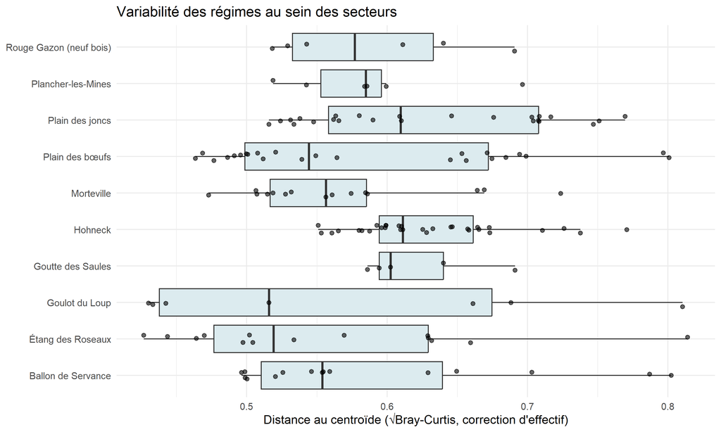

```r
p_disp <- ggplot(disp_result$distances, aes(x = secteur, y = distance)) +
  geom_boxplot(outlier.shape = NA, fill = "#dcebef") +
  geom_jitter(width = .12, height = 0, alpha = .6, size = 1.7) + coord_flip() +
  labs(x = NULL, y = "Distance au centroïde (√Bray-Curtis, correction d'effectif)",
       title = "Variabilité des régimes au sein des secteurs")
p_disp
```

```r
save_plot(p_disp, "dispersion_par_secteur.png")
export_csv(disp_result$test, "test_dispersion.csv")
```

```r
if (disp_result$test$p < .05) {
  cat("**Les dispersions diffèrent entre secteurs.** Le signal de la PERMANOVA ne peut donc pas être attribué uniquement aux compositions moyennes. Les comparaisons restent exploratoires.\n")
} else {
  cat("Le test ne met pas en évidence de différence de dispersion au seuil de 5 %. Cela ne prouve pas l'égalité des dispersions, particulièrement pour les petits effectifs.\n")
}
```

Le test ne met pas en évidence de différence de dispersion au seuil de 5 %. Cela ne prouve pas l’égalité des dispersions, particulièrement pour les petits effectifs.

## 3.4 Comparaisons par paires

On ne compare que les **mois présents dans les deux secteurs**. Une paire sans mois commun n’est pas testée : les effets du secteur et du mois seraient confondus. La correction de Holm porte sur toutes les paires estimables.

```r
set.seed(params$seed + 30L)
pair_list <- list(); no_overlap <- list()
for (ab in combn(secteurs_principaux, 2, simplify = FALSE)) {
  shared <- intersect(meta$mois[meta$secteur %in% ab[1]], meta$mois[meta$secteur %in% ab[2]])
  shared <- shared[!is.na(shared)]
  if (!length(shared)) {
    no_overlap[[length(no_overlap)+1L]] <- data.frame(secteur_1 = ab[1], secteur_2 = ab[2])
    next
  }
  ii <- meta$secteur %in% ab & meta$mois %in% shared
  pair_list[[length(pair_list)+1L]] <- cbind(
    data.frame(secteur_1 = ab[1], secteur_2 = ab[2], mois_communs = paste(sort(shared), collapse = ", ")),
    permanova_conditionnelle(D[ii, ii, drop = FALSE], meta$secteur[ii], meta$mois[ii],
                              nperm = params$nperm_pairwise))
}
pairwise <- bind_rows(pair_list)
if (nrow(pairwise)) {
  pairwise$p_Holm <- p.adjust(pairwise$p, method = "holm")
  pairwise <- pairwise %>% arrange(p_Holm, secteur_1, secteur_2)
  tab(pairwise)
  export_csv(pairwise, "permanova_comparaisons_paires.csv")
}
paires_non_testees <- bind_rows(no_overlap)
if (nrow(paires_non_testees)) tab(paires_non_testees)
```

| secteur_1 | secteur_2 |
| --- | --- |
| Plain des joncs | Goutte des Saules |
| Ballon de Servance | Goutte des Saules |
| Étang des Roseaux | Goulot du Loup |
| Goulot du Loup | Plancher-les-Mines |
| Goulot du Loup | Goutte des Saules |
| Rouge Gazon (neuf bois) | Goutte des Saules |

# 4 Recherche de groupes alimentaires

Les coordonnées et les secteurs **ne sont pas utilisés pour construire les groupes**. Les groupes sont ensuite confrontés à la géographie. La classification PAM est calculée sur les distances de Bray-Curtis. Le nombre de groupes est exploré entre 2 et 8, puis choisi selon la silhouette moyenne, parmi les partitions dont chaque groupe contient au moins 5 fèces. Ce seuil est un choix d’exploration et non une propriété biologique.

## 4.1 Choix du nombre de groupes et stabilité

```r
set.seed(params$seed + 40L)
k_values <- seq.int(2L, min(as.integer(params$k_max), nrow(P)-1L))
fit_pam <- function(d, k) cluster::pam(as.dist(d), k = k, diss = TRUE,
                                      do.swap = TRUE, pamonce = 0,
                                      keep.diss = FALSE, keep.data = FALSE)
fits <- lapply(k_values, function(k) fit_pam(D, k))
cluster_choices <- bind_rows(lapply(seq_along(k_values), function(j) {
  cl <- fits[[j]]$clustering
  sizes <- table(cl)
  data.frame(k = k_values[j], silhouette = mean(cluster::silhouette(cl, as.dist(D))[, 3]),
             effectif_min = min(sizes), effectifs = paste(as.integer(sizes), collapse = ", "))
}))
eligible <- which(cluster_choices$effectif_min >= params$min_cluster_size)
if (!length(eligible)) {
  warning("Aucune partition ne respecte le seuil d'effectif : choix exploratoire sans cette contrainte.")
  eligible <- seq_len(nrow(cluster_choices))
}
best <- eligible[which.max(cluster_choices$silhouette[eligible])]
k <- cluster_choices$k[best]
chosen <- fits[[best]]$clustering
# Numéros lisibles : groupe 1 = le plus grand, etc.
order_groups <- names(sort(table(chosen), decreasing = TRUE))
meta$groupe <- match(as.character(chosen), order_groups)
cluster_choices$retenu <- cluster_choices$k == k
tab(cluster_choices)
```

| k | silhouette | effectif_min | effectifs | retenu |
| --- | --- | --- | --- | --- |
| 2 | 0.145 | 43 | 111, 43 | FALSE |
| 3 | 0.175 | 37 | 37, 77, 40 | FALSE |
| 4 | 0.177 | 30 | 34, 37, 53, 30 | FALSE |
| 5 | 0.202 | 10 | 34, 34, 50, 10, 26 | FALSE |
| 6 | 0.217 | 9 | 15, 50, 23, 31, 9, 26 | FALSE |
| 7 | 0.221 | 9 | 15, 49, 22, 25, 16, 9, 18 | FALSE |
| 8 | 0.236 | 6 | 12, 49, 21, 25, 15, 9, 17, 6 | TRUE |

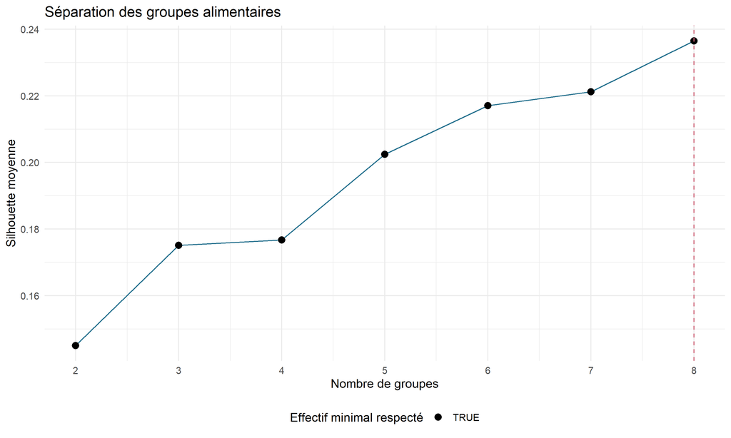

```r
p_sil <- ggplot(cluster_choices, aes(k, silhouette)) + geom_line(color = "#216e8c") +
  geom_point(aes(shape = effectif_min >= params$min_cluster_size), size = 3) +
  geom_vline(xintercept = k, linetype = 2, color = "#ce6679") +
  scale_x_continuous(breaks = k_values) +
  labs(x = "Nombre de groupes", y = "Silhouette moyenne", shape = "Effectif minimal respecté",
       title = "Séparation des groupes alimentaires") + theme(legend.position = "bottom")
p_sil
```

```r
save_plot(p_sil, "choix_nombre_groupes.png")

ari <- replicate(params$n_subsamples, {
  ii <- sort(sample.int(nrow(P), size = floor(.8*nrow(P)), replace = FALSE))
  z <- fit_pam(D[ii, ii, drop = FALSE], k)$clustering
  adjusted_rand(meta$groupe[ii], z)
})
ward <- cutree(hclust(dist(sqrt(P)), method = "ward.D2"), k = k)
average2 <- cutree(hclust(as.dist(D), method = "average"), k = 2)
stabilite <- data.frame(
  k = k, silhouette = cluster_choices$silhouette[best],
  ARI_mediane_sous_echantillons = median(ari),
  ARI_quantile_10 = unname(quantile(ari, .1)),
  ARI_Ward_Hellinger = adjusted_rand(meta$groupe, ward),
  repetitions = params$n_subsamples)
tab(stabilite)
```

| k | silhouette | ARI_mediane_sous_echantillons | ARI_quantile_10 | ARI_Ward_Hellinger | repetitions |
| --- | --- | --- | --- | --- | --- |
| 8 | 0.236 | 0.768 | 0.61 | 0.506 | 200 |

```r
export_csv(cluster_choices, "choix_nombre_groupes.csv")
export_csv(stabilite, "stabilite_groupes.csv")
```

La partition présentée comporte **8 groupes**, avec une silhouette moyenne de **0.236**. Une silhouette faible indique une séparation peu marquée. L’indice de Rand ajusté (ARI) décrit l’accord avec la partition initiale lors de sous-échantillonnages de 80 % des fèces, puis avec une méthode différente (Ward sur profils de Hellinger). **Ce diagnostic ne démontre pas l’existence de 8 unités écologiques distinctes.**

La classification hiérarchique moyenne à deux groupes donne ici des effectifs 153 et 1, utile pour repérer une classification dominée par l’isolement de profils atypiques.

## 4.2 Composition des groupes et répartition par secteur

```r
profils <- bind_rows(lapply(seq_len(k), function(z) {
  avg <- colMeans(P[meta$groupe == z, , drop = FALSE])
  top <- names(sort(avg, decreasing = TRUE))[seq_len(min(6, length(avg)))]
  data.frame(groupe = z, n = sum(meta$groupe == z), taxon = top,
             nom_taxon = label_taxon(top), proportion_moyenne = avg[top], row.names = NULL)
}))
tab(profils %>% mutate(pourcentage = 100*proportion_moyenne) %>%
      select(groupe, n, nom_taxon, pourcentage), digits = 1)
```

| groupe | n | nom_taxon | pourcentage |
| --- | --- | --- | --- |
| 1 | 49 | Rosacées | 63.0 |
| 1 | 49 | Bétulacées | 3.0 |
| 1 | 49 | Framboisier | 2.7 |
| 1 | 49 | Myrtille | 2.5 |
| 1 | 49 | Oléacées | 2.2 |
| 1 | 49 | Érables | 2.1 |
| 2 | 25 | Myrtille | 26.2 |
| 2 | 25 | Rosacées | 16.9 |
| 2 | 25 | Bétulacées | 9.5 |
| 2 | 25 | Framboisier | 5.3 |
| 2 | 25 | Vaccinium | 5.1 |
| 2 | 25 | Érables | 4.2 |
| 3 | 21 | Framboisier | 24.6 |
| 3 | 21 | Reine-des-prés | 11.1 |
| 3 | 21 | Ceratodon (mousse) | 10.7 |
| 3 | 21 | Rosacées | 9.5 |
| 3 | 21 | Gentiana | 4.7 |
| 3 | 21 | Myrtille | 4.5 |
| 4 | 17 | Oléacées | 34.5 |
| 4 | 17 | Érables | 15.0 |
| 4 | 17 | Rosacées | 11.4 |
| 4 | 17 | Ormes | 10.6 |
| 4 | 17 | Campylopusflexuosus | 3.9 |
| 4 | 17 | Tilia | 3.2 |
| 5 | 15 | Érables | 37.5 |
| 5 | 15 | Rosacées | 11.7 |
| 5 | 15 | Fagussylvatica | 8.8 |
| 5 | 15 | Grimmiahartmanii | 5.0 |
| 5 | 15 | Bétulacées | 4.0 |
| 5 | 15 | Framboisier | 3.7 |
| 6 | 12 | Renouée bistorte | 21.4 |
| 6 | 12 | Betula | 9.1 |
| 6 | 12 | Rumexacetosa | 8.7 |
| 6 | 12 | Melampyrumpratense | 7.1 |
| 6 | 12 | Poaceae | 6.6 |
| 6 | 12 | Asteraceae | 5.5 |
| 7 | 9 | Sapins | 60.1 |
| 7 | 9 | Dicranumscoparium | 8.1 |
| 7 | 9 | Rosacées | 6.6 |
| 7 | 9 | Urticadioica | 5.3 |
| 7 | 9 | Leucobryum | 5.1 |
| 7 | 9 | Dicranellaheteromalla | 3.1 |
| 8 | 6 | Hypnales | 44.1 |
| 8 | 6 | Lewinskya | 17.3 |
| 8 | 6 | Magnoliopsida | 17.0 |
| 8 | 6 | Polytrichumformosum | 9.9 |
| 8 | 6 | Dicranumscoparium | 4.5 |
| 8 | 6 | Sciuro_hypnum | 2.3 |

```r
repartition <- as.data.frame.matrix(table(meta$secteur, meta$groupe))
repartition <- data.frame(secteur = rownames(repartition), repartition, check.names = FALSE)
tab(repartition)
```

|  | secteur | 1 | 2 | 3 | 4 | 5 | 6 | 7 | 8 |
| --- | --- | --- | --- | --- | --- | --- | --- | --- | --- |
| Ballon de Servance | Ballon de Servance | 1 | 1 | 1 | 4 | 6 | 0 | 0 | 2 |
| Bois Malvaux | Bois Malvaux | 1 | 0 | 0 | 0 | 0 | 0 | 0 | 0 |
| Étang des Roseaux | Étang des Roseaux | 4 | 7 | 2 | 0 | 0 | 0 | 0 | 1 |
| Goulot du Loup | Goulot du Loup | 5 | 0 | 0 | 0 | 2 | 0 | 0 | 0 |
| Goutte des saules | Goutte des saules | 0 | 2 | 0 | 0 | 1 | 0 | 0 | 0 |
| Goutte des Saules | Goutte des Saules | 2 | 0 | 0 | 0 | 0 | 0 | 3 | 0 |
| Hohneck | Hohneck | 3 | 1 | 16 | 0 | 0 | 11 | 0 | 0 |
| Morteville | Morteville | 5 | 3 | 2 | 3 | 2 | 0 | 0 | 0 |
| Plain-des-boeufs | Plain-des-boeufs | 0 | 2 | 0 | 0 | 0 | 0 | 0 | 0 |
| Plain des bœufs | Plain des bœufs | 13 | 2 | 0 | 4 | 2 | 1 | 2 | 0 |
| Plain des joncs | Plain des joncs | 11 | 4 | 0 | 2 | 1 | 0 | 3 | 3 |
| Plancher-les-Mines | Plancher-les-Mines | 3 | 0 | 0 | 2 | 0 | 0 | 1 | 0 |
| Rouge Gazon (neuf bois) | Rouge Gazon (neuf bois) | 1 | 2 | 0 | 2 | 1 | 0 | 0 | 0 |

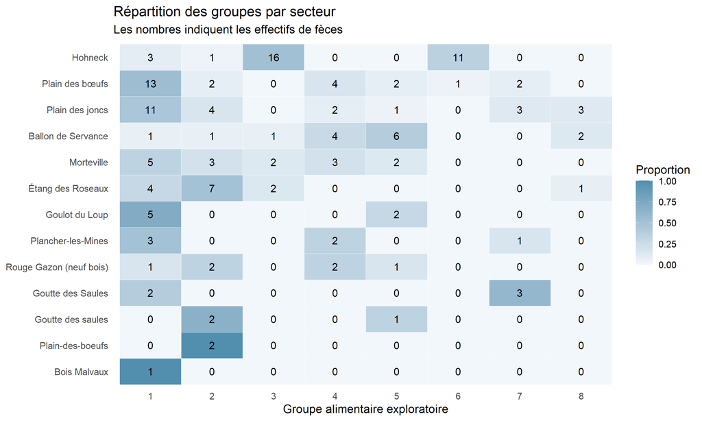

```r
export_csv(profils, "composition_groupes.csv")
export_csv(repartition, "groupes_par_secteur.csv")

heat <- meta %>% filter(!is.na(secteur)) %>%
  count(secteur, groupe, name = "n") %>%
  complete(secteur, groupe = seq_len(k), fill = list(n = 0)) %>%
  group_by(secteur) %>% mutate(proportion = n/sum(n)) %>% ungroup()
heat$secteur <- factor(heat$secteur, levels = rev(effectifs$secteur))
p_heat <- ggplot(heat, aes(factor(groupe), secteur, fill = proportion)) +
  geom_tile(color = "white") + geom_text(aes(label = n), size = 3.8) +
  scale_fill_gradient(low = "#f2f7fb", high = "#528faf", limits = c(0, 1)) +
  labs(x = "Groupe alimentaire exploratoire", y = NULL, fill = "Proportion",
       title = "Répartition des groupes par secteur", subtitle = "Les nombres indiquent les effectifs de fèces") +
  theme(panel.grid = element_blank())
p_heat
```

```r
save_plot(p_heat, "groupes_par_secteur.png", height = 7)
```

## 4.3 Lecture des profils alimentaires et de leur répartition

Le tableau ci-dessous rapproche automatiquement les taxons dominants de chaque groupe et les secteurs où ses fèces sont les plus nombreuses. Il se recalcule si le nombre de groupes ou leurs affectations changent. Les secteurs sont classés par **nombre de fèces du groupe**, pas par significativité statistique.

```r
synthese_profils <- bind_rows(lapply(seq_len(k), function(z) {
  taxons <- profils %>% filter(groupe == z) %>%
    arrange(desc(proportion_moyenne)) %>% head(3)
  par_secteur <- meta %>% filter(groupe == z, !is.na(secteur)) %>%
    count(secteur, name = "n_groupe") %>%
    left_join(effectifs %>% rename(n_secteur = n), by = "secteur") %>%
    arrange(desc(n_groupe), secteur) %>% head(2)
  data.frame(
    Groupe = z,
    Nombre_de_feces = sum(meta$groupe == z),
    Principaux_taxons = paste(paste0(taxons$nom_taxon, " (",
                                     round(100*taxons$proportion_moyenne, 1), " %)"),
                              collapse = "; "),
    Secteurs_les_plus_representes = paste(
      paste0(par_secteur$secteur, " (", par_secteur$n_groupe, "/",
             par_secteur$n_secteur, " fèces du secteur)"), collapse = "; "),
    check.names = FALSE)
}))
tab(synthese_profils)
```

| Groupe | Nombre_de_feces | Principaux_taxons | Secteurs_les_plus_representes |
| --- | --- | --- | --- |
| 1 | 49 | Rosacées (63 %); Bétulacées (3 %); Framboisier (2.7 %) | Plain des bœufs (13/24 fèces du secteur); Plain des joncs (11/24 fèces du secteur) |
| 2 | 25 | Myrtille (26.2 %); Rosacées (16.9 %); Bétulacées (9.5 %) | Étang des Roseaux (7/14 fèces du secteur); Plain des joncs (4/24 fèces du secteur) |
| 3 | 21 | Framboisier (24.6 %); Reine-des-prés (11.1 %); Ceratodon (mousse) (10.7 %) | Hohneck (16/31 fèces du secteur); Morteville (2/15 fèces du secteur) |
| 4 | 17 | Oléacées (34.5 %); Érables (15 %); Rosacées (11.4 %) | Ballon de Servance (4/15 fèces du secteur); Plain des bœufs (4/24 fèces du secteur) |
| 5 | 15 | Érables (37.5 %); Rosacées (11.7 %); Fagussylvatica (8.8 %) | Ballon de Servance (6/15 fèces du secteur); Goulot du Loup (2/7 fèces du secteur) |
| 6 | 12 | Renouée bistorte (21.4 %); Betula (9.1 %); Rumexacetosa (8.7 %) | Hohneck (11/31 fèces du secteur); Plain des bœufs (1/24 fèces du secteur) |
| 7 | 9 | Sapins (60.1 %); Dicranumscoparium (8.1 %); Rosacées (6.6 %) | Goutte des Saules (3/5 fèces du secteur); Plain des joncs (3/24 fèces du secteur) |
| 8 | 6 | Hypnales (44.1 %); Lewinskya (17.3 %); Magnoliopsida (17 %) | Plain des joncs (3/24 fèces du secteur); Ballon de Servance (2/15 fèces du secteur) |

```r
export_csv(synthese_profils, "synthese_profils_et_secteurs.csv")
```

Les taxons dominants sont des moyennes descriptives : ils ne caractérisent pas nécessairement chaque fèces du groupe. Une association apparente à un secteur ne signifie pas que le profil lui est exclusif, ni qu’il s’agit d’une préférence alimentaire. Les numéros des groupes sont des étiquettes et ne représentent pas des distances entre régimes.

```r
if (stabilite$silhouette < .25) {
  cat("**Les groupes sont peu séparés et se chevauchent.** Ils doivent être présentés comme des profils alimentaires exploratoires, plutôt que comme des régimes nettement distincts.\n")
} else {
  cat("La silhouette décrit la séparation des groupes, mais ne suffit pas à démontrer des unités écologiques distinctes. L'accord entre méthodes et la stabilité doivent également être considérés.\n")
}
```

**Les groupes sont peu séparés et se chevauchent.** Ils doivent être présentés comme des profils alimentaires exploratoires, plutôt que comme des régimes nettement distincts.

## 4.4 Ordination des régimes

Les deux premiers axes de la PCoA résument les distances de Bray-Curtis. Les pourcentages sont rapportés à l’inertie des axes positifs. Des axes négatifs peuvent exister avec cette distance ; la figure ne représente pas toute la variation des régimes. Aucun contour géographique ou intervalle de confiance n’est déduit de cette ordination.

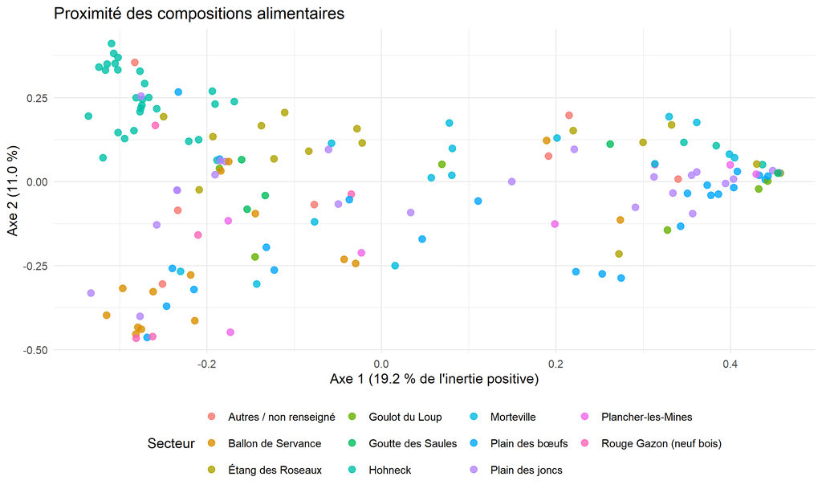

```r
eg <- eigen(center_distance(D), symmetric = TRUE)
if (sum(eg$values > 1e-10) < 2) stop("Moins de deux axes positifs pour la PCoA.")
xy_pcoa <- sweep(eg$vectors[, 1:2, drop = FALSE], 2, sqrt(eg$values[1:2]), "*")
pct <- 100*eg$values[1:2]/sum(eg$values[eg$values > 0])
pcoa_df <- data.frame(meta, Axe1 = xy_pcoa[, 1], Axe2 = xy_pcoa[, 2])
pcoa_df$secteur_affiche <- ifelse(pcoa_df$secteur %in% secteurs_principaux,
                                  pcoa_df$secteur, "Autres / non renseigné")
p_pcoa <- ggplot(pcoa_df, aes(Axe1, Axe2, color = secteur_affiche)) +
  geom_point(size = 2.6, alpha = .8) +
  labs(x = sprintf("Axe 1 (%.1f %% de l'inertie positive)", pct[1]),
       y = sprintf("Axe 2 (%.1f %%)", pct[2]), color = "Secteur",
       title = "Proximité des compositions alimentaires") +
  theme(legend.position = "bottom")
p_pcoa
```

```r
save_plot(p_pcoa, "ordination_pcoa.png")
export_csv(pcoa_df, "coordonnees_pcoa_et_groupes.csv")
```

## 4.5 Évolution saisonnière des groupes

Les groupes sont construits tous mois confondus. Un groupe peut donc refléter une saison autant qu’un secteur. Le tableau et la figure permettent de vérifier ce point, notamment pour le Hohneck.

```r
tab(as.data.frame.matrix(table(meta$groupe, meta$mois)), row.names = TRUE)
```

|  | 7 | 8 | 9 | 10 |
| --- | --- | --- | --- | --- |
| 1 | 11 | 19 | 8 | 11 |
| 2 | 5 | 7 | 6 | 7 |
| 3 | 0 | 3 | 2 | 16 |
| 4 | 5 | 1 | 2 | 9 |
| 5 | 8 | 4 | 0 | 3 |
| 6 | 7 | 2 | 2 | 1 |
| 7 | 2 | 1 | 5 | 1 |
| 8 | 0 | 4 | 1 | 1 |

```r
hohneck <- meta %>% filter(secteur == "Hohneck")
if (nrow(hohneck)) tab(as.data.frame.matrix(table(hohneck$groupe, hohneck$mois)), row.names = TRUE)
```

|  | 7 | 8 | 9 | 10 |
| --- | --- | --- | --- | --- |
| 1 | 0 | 2 | 1 | 0 |
| 2 | 0 | 0 | 0 | 1 |
| 3 | 0 | 1 | 0 | 15 |
| 6 | 7 | 2 | 2 | 0 |

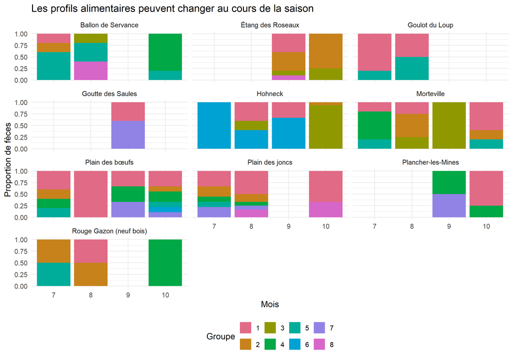

```r
group_colors <- setNames(grDevices::hcl.colors(k, "Dark 3"), as.character(seq_len(k)))
season <- meta %>% filter(secteur %in% secteurs_principaux, !is.na(mois)) %>%
  count(secteur, mois, groupe, name = "n")
p_season <- ggplot(season, aes(factor(mois), n, fill = factor(groupe))) +
  geom_col(position = "fill") + facet_wrap(~secteur, ncol = 3) +
  scale_fill_manual(values = group_colors, drop = FALSE) +
  labs(x = "Mois", y = "Proportion de fèces", fill = "Groupe",
       title = "Les profils alimentaires peuvent changer au cours de la saison") +
  theme(legend.position = "bottom")
p_season
```

```r
save_plot(p_season, "groupes_par_mois_et_secteur.png", height = 7)
```

# 5 Organisation spatiale des régimes

## 5.1 Données utilisables et test spatial

L’analyse spatiale porte uniquement sur les positions appariées au GPKG et un mois renseigné. Les coordonnées brutes non appariées ne sont **ni corrigées arbitrairement, ni utilisées**. Des secteurs peuvent donc figurer dans la comparaison des régimes sans être couverts par le test spatial.

On calcule un indice de Moran multivarié sur les profils de Hellinger après retrait de l’effet du mois :

$$I = \frac{n}{\sum_{ij} w_{ij}}\,
\frac{\mathrm{tr}(R^\top W R)}{\mathrm{tr}(R^\top R)}.$$

Le graphe des plus proches voisins est symétrisé et tous les voisins ex æquo sont conservés. Le test est unilatéral pour une autocorrélation positive, par permutation des profils résiduels au sein du mois. Le graphe reste fixe.

```r
set.seed(params$seed + 50L)
if (sum(spatial) <= 8) stop("Moins de neuf fèces appariées : analyse spatiale non réalisable.")
spatial_tests <- bind_rows(lapply(c(3L, 5L, 8L), function(kk)
  spatial_moran(P[spatial, , drop = FALSE],
                 as.matrix(meta[spatial, c("est", "nord")]), meta$mois[spatial], k = kk)))
spatial_tests$p_Holm <- p.adjust(spatial_tests$p, method = "holm")
tab(spatial_tests)
```

| n | voisins | I | p | permutations | p_Holm |
| --- | --- | --- | --- | --- | --- |
| 115 | 3 | 0.187 | 0 | 4999 | 0.001 |
| 115 | 5 | 0.166 | 0 | 4999 | 0.001 |
| 115 | 8 | 0.139 | 0 | 4999 | 0.001 |

```r
export_csv(spatial_tests, "autocorrelation_spatiale.csv")

# Sensibilité : même poids par secteur × mois, médiane des positions de collecte.
spatial_agg_mask <- spatial & !is.na(meta$secteur)
agg_spatial <- aggregate_sector_month(P[spatial_agg_mask, , drop = FALSE],
                                      meta[spatial_agg_mask, , drop = FALSE])
spatial_agg_test <- spatial_moran(agg_spatial$P,
                                  as.matrix(agg_spatial$meta[, c("est", "nord")]),
                                  agg_spatial$meta$mois, k = 3L)
tab(spatial_agg_test)
```

| n | voisins | I | p | permutations |
| --- | --- | --- | --- | --- |
| 25 | 3 | 0.154 | 0 | 4999 |

```r
export_csv(spatial_agg_test, "autocorrelation_moyennes_secteur_mois.csv")

couverture <- meta %>% filter(!is.na(secteur)) %>% group_by(secteur) %>%
  summarise(n_regimes = n(), n_cartographiables = sum(coord_appariees), .groups = "drop")
tab(couverture)
```

| secteur | n_regimes | n_cartographiables |
| --- | --- | --- |
| Ballon de Servance | 15 | 15 |
| Bois Malvaux | 1 | 0 |
| Goulot du Loup | 7 | 7 |
| Goutte des Saules | 5 | 5 |
| Goutte des saules | 3 | 3 |
| Hohneck | 31 | 31 |
| Morteville | 15 | 15 |
| Plain des bœufs | 24 | 24 |
| Plain des joncs | 24 | 0 |
| Plain-des-boeufs | 2 | 2 |
| Plancher-les-Mines | 6 | 6 |
| Rouge Gazon (neuf bois) | 6 | 6 |
| Étang des Roseaux | 14 | 0 |

```r
export_csv(couverture, "couverture_cartographique_par_secteur.csv")
```

Ce test recherche une **ressemblance accrue entre profils voisins**. Il ne recherche pas de frontières, ne détermine pas un nombre de clusters géographiques et ne démontre pas que chaque groupe alimentaire est propre à une zone.

## 5.2 Carte exploratoire

Les disques sont placés à la médiane des coordonnées de chaque secteur apparié. Les parts représentent les groupes alimentaires parmi les seules fèces cartographiables du secteur. Les rayons sont fixes et ne représentent pas les effectifs. L’échelle correspond à des kilomètres dans un repère local Lambert-93. La carte n’affiche pas de limites de zones alimentaires.

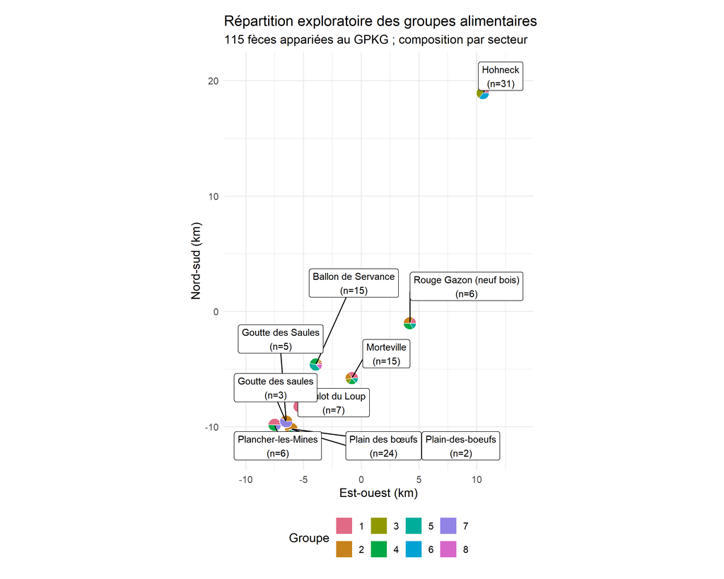

```r
carto <- meta[spatial & !is.na(meta$secteur), , drop = FALSE]
if (!nrow(carto)) stop("Aucun secteur cartographiable.")
origin <- colMeans(meta[spatial, c("est", "nord"), drop = FALSE])
centers <- carto %>% group_by(secteur) %>%
  summarise(x = (median(est)-origin[1])/1000,
            y = (median(nord)-origin[2])/1000, n = n(), .groups = "drop")
parts <- carto %>% count(secteur, groupe, name = "n_groupe") %>%
  complete(secteur, groupe = seq_len(k), fill = list(n_groupe = 0)) %>%
  left_join(centers, by = "secteur") %>% group_by(secteur) %>% arrange(groupe, .by_group = TRUE) %>%
  mutate(prop = n_groupe/sum(n_groupe), fin = cumsum(prop)*2*pi,
         debut = lag(fin, default = 0)) %>% ungroup()
polygons <- bind_rows(lapply(seq_len(nrow(parts)), function(i) {
  z <- parts[i, ]
  if (z$prop == 0) return(NULL)
  theta <- seq(z$debut, z$fin, length.out = max(3, ceiling(80*z$prop)))
  radius <- .55
  data.frame(secteur = z$secteur, groupe = z$groupe,
             x = c(z$x, z$x+radius*cos(theta), z$x),
             y = c(z$y, z$y+radius*sin(theta), z$y))
}))
p_map <- ggplot() +
  geom_polygon(data = polygons, aes(x, y, group = interaction(secteur, groupe),
                                    fill = factor(groupe)), color = "white", linewidth = .3) +
  ggrepel::geom_label_repel(data = centers, aes(x, y, label = paste0(secteur, "\n(n=", n, ")")),
                            seed = params$seed, size = 3.4, max.overlaps = Inf,
                            min.segment.length = 0, box.padding = .7) +
  scale_fill_manual(values = group_colors, drop = FALSE) + coord_equal(clip = "off") +
  scale_x_continuous(expand = expansion(mult = .2)) +
  scale_y_continuous(expand = expansion(mult = .1)) +
  labs(x = "Est-ouest (km)", y = "Nord-sud (km)", fill = "Groupe",
       title = "Répartition exploratoire des groupes alimentaires",
       subtitle = paste(sum(spatial), "fèces appariées au GPKG ; composition par secteur")) +
  theme(legend.position = "bottom", plot.margin = margin(15, 35, 15, 35))
p_map
```

```r
save_plot(p_map, "carte_groupes_alimentaires.png", height = 8)
```

# 6 Distance alimentaire et distance géographique

Cette analyse répond à une question différente de la classification : **plus deux fèces sont éloignées dans l’espace, plus leurs compositions alimentaires sont-elles différentes ?** La distance alimentaire est Bray-Curtis sur les profils normalisés ; la distance géographique est la distance euclidienne en kilomètres en Lambert-93. Les numéros des clusters n’entrent pas dans le calcul de la distance alimentaire.

Une corrélation de Spearman entre matrices est calculée. Les permutations réaffectent les échantillons (lignes et colonnes ensemble), et non les paires séparément : les milliers de paires ne sont pas des observations indépendantes. Le test unilatéral cherche une association positive. Il s’agit d’une exploration : une corrélation ne démontre ni un effet causal de l’éloignement ni un gradient continu, et les dépendances spatiales/individuelles limitent les p-values de Mantel.

L’analyse privilégiée ne conserve que les **paires du même mois**, avec permutation des échantillons au sein de chaque mois. Elle évite ainsi de comparer directement un régime de juillet à un régime d’octobre. La corrélation reste une statistique regroupée sur les paires de plusieurs mois, et non une régression contrôlant toutes les variations saisonnières.

```r
mantel_distance <- function(p, md, same_month = TRUE, perm_month = TRUE,
                            nperm = params$nperm) {
  if (nrow(p) != nrow(md) || anyNA(md$mois))
    stop("Données et métadonnées mal alignées pour la comparaison de distances.")
  if (same_month && !perm_month)
    stop("Le masque même mois requiert des permutations au sein des mois.")
  db <- as.matrix(vegan::vegdist(p, method = "bray"))
  dg <- as.matrix(dist(as.matrix(md[, c("est", "nord")]))) / 1000
  pairs <- which(upper.tri(db), arr.ind = TRUE)
  if (same_month)
    pairs <- pairs[md$mois[pairs[, 1]] == md$mois[pairs[, 2]], , drop = FALSE]
  if (nrow(pairs) < 3) stop("Moins de trois paires utilisables.")
  # Les rangs des paires retenues sont conservés par les permutations intra-mois.
  # Les égalités (positions identiques, distances identiques) reçoivent le rang moyen.
  ranks_b <- rank(db[pairs], ties.method = "average")
  ranks_g <- rank(dg[pairs], ties.method = "average")
  ranks_g <- ranks_g - mean(ranks_g)
  ranks_b_centered <- ranks_b - mean(ranks_b)
  norm_g <- sqrt(sum(ranks_g^2))
  norm_b <- sqrt(sum(ranks_b_centered^2))
  if (norm_g == 0 || norm_b == 0) stop("Distances constantes : corrélation non définie.")
  observed <- sum(ranks_b_centered*ranks_g)/(norm_b*norm_g)
  rank_matrix <- matrix(0, nrow(db), ncol(db))
  rank_matrix[pairs] <- ranks_b
  rank_matrix[pairs[, 2:1, drop = FALSE]] <- ranks_b
  blocks <- if (perm_month) md$mois else rep(1L, nrow(md))
  ge <- 0L
  for (i in seq_len(nperm)) {
    pp <- perm_index(blocks)
    index <- cbind(pp[pairs[, 1]], pp[pairs[, 2]])
    values <- rank_matrix[index]
    values <- values - mean(values)
    rho <- sum(values*ranks_g)/(sqrt(sum(values^2))*norm_g)
    ge <- ge + (rho >= observed - 1e-12)
  }
  list(test = data.frame(n = nrow(md), n_paires = nrow(pairs),
                         rho_Spearman = observed, p = (ge+1)/(nperm+1),
                         paires_meme_mois = same_month,
                         permutations_intra_mois = perm_month,
                         distance_max_km = max(dg), permutations = nperm),
       pairs = data.frame(id_1 = md$N_Antagene[pairs[, 1]],
                          id_2 = md$N_Antagene[pairs[, 2]],
                          distance_km = dg[pairs], distance_Bray_Curtis = db[pairs],
                          mois_1 = md$mois[pairs[, 1]], mois_2 = md$mois[pairs[, 2]]))
}
```

## 6.1 Relation globale et sensibilités

```r
set.seed(params$seed + 60L)
md_distance <- meta[spatial, , drop = FALSE]
p_distance <- P[spatial, , drop = FALSE]
mt_global <- mantel_distance(p_distance, md_distance, same_month = FALSE, perm_month = FALSE)
mt_global_mois <- mantel_distance(p_distance, md_distance, same_month = FALSE, perm_month = TRUE)
mt_meme_mois <- mantel_distance(p_distance, md_distance, same_month = TRUE, perm_month = TRUE)

# Sensibilité au contraste Hohneck / reste de l'aire échantillonnée.
# Dans les données initiales, les positions appariées au nord de 48°N sont
# celles du Hohneck et une fèces voisine sans secteur renseigné.
# Ce seuil définit ce sous-ensemble géographique pour ce projet ; il doit être
# revu si l'aire d'étude change. La portée des distances diminue après exclusion.
hors_hohneck <- md_distance$latitude_gpkg < 48
mt_hors_hohneck <- NULL
if (sum(hors_hohneck) >= 5) {
  mt_hors_hohneck <- mantel_distance(p_distance[hors_hohneck, , drop = FALSE],
                                    md_distance[hors_hohneck, , drop = FALSE],
                                    same_month = TRUE, perm_month = TRUE)
}

# Les 21 unités secteur × mois cartographiables ont ici le même poids.
md_ag_dist <- agg_spatial$meta
md_ag_dist$N_Antagene <- paste(md_ag_dist$secteur, md_ag_dist$mois, sep = "__")
mt_agrege <- mantel_distance(agg_spatial$P, md_ag_dist,
                            same_month = TRUE, perm_month = TRUE)
distance_tests <- bind_rows(
  cbind(Analyse = "Toutes paires ; permutations libres", mt_global$test),
  cbind(Analyse = "Toutes paires ; permutations intra-mois", mt_global_mois$test),
  cbind(Analyse = "Paires du même mois ; permutations intra-mois", mt_meme_mois$test),
  if (!is.null(mt_hors_hohneck))
    cbind(Analyse = "Sans les positions du Hohneck ; paires du même mois", mt_hors_hohneck$test),
  cbind(Analyse = "Moyennes secteur × mois ; paires du même mois", mt_agrege$test))
tab(distance_tests)
```

| Analyse | n | n_paires | rho_Spearman | p | paires_meme_mois | permutations_intra_mois | distance_max_km | permutations |
| --- | --- | --- | --- | --- | --- | --- | --- | --- |
| Toutes paires ; permutations libres | 115 | 6555 | 0.373 | 0.000 | FALSE | FALSE | 34.983 | 4999 |
| Toutes paires ; permutations intra-mois | 115 | 6555 | 0.373 | 0.000 | FALSE | TRUE | 34.983 | 4999 |
| Paires du même mois ; permutations intra-mois | 115 | 1765 | 0.398 | 0.000 | TRUE | TRUE | 34.983 | 4999 |
| Sans les positions du Hohneck ; paires du même mois | 83 | 862 | 0.008 | 0.298 | TRUE | TRUE | 14.690 | 4999 |
| Moyennes secteur × mois ; paires du même mois | 25 | 66 | 0.281 | 0.026 | TRUE | TRUE | 34.979 | 4999 |

```r
export_csv(distance_tests, "correlation_distances_alimentaires_geographiques.csv")
export_csv(mt_meme_mois$pairs, "distances_par_paire_meme_mois.csv")
```

Les tests sont des analyses principale et de sensibilité, et non cinq preuves indépendantes. L’absence d’association après retrait du Hohneck ne prouve pas que ce secteur est l’unique mécanisme : l’étendue spatiale et la puissance diminuent aussi lorsqu’on l’exclut.

## 6.2 Représentation des distances

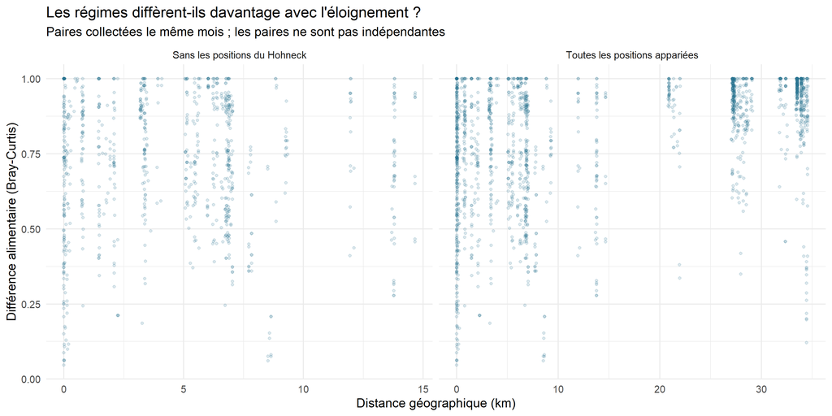

```r
distance_plot <- bind_rows(
  transform(mt_meme_mois$pairs, analyse = "Toutes les positions appariées"),
  if (!is.null(mt_hors_hohneck))
    transform(mt_hors_hohneck$pairs, analyse = "Sans les positions du Hohneck"))
p_distances <- ggplot(distance_plot, aes(distance_km, distance_Bray_Curtis)) +
  geom_point(alpha = .15, size = 1, color = "#216e8c") +
  facet_wrap(~analyse, nrow = 1, scales = "free_x") +
  labs(x = "Distance géographique (km)", y = "Différence alimentaire (Bray-Curtis)",
       title = "Les régimes diffèrent-ils davantage avec l'éloignement ?",
       subtitle = "Paires collectées le même mois ; les paires ne sont pas indépendantes")
p_distances
```

```r
save_plot(p_distances, "distance_alimentaire_vs_geographique.png", width = 11, height = 5.5)
```

Il n’est pas ajouté de régression ordinaire avec p-value ou bande de confiance traitant chaque paire comme indépendante. La relation est évaluée par permutation des échantillons.

## 6.3 Interprétation calculée

Sur les 115 fèces géolocalisées, la corrélation calculée sur les paires du même mois est **rho = 0.398** (p < 0,001). En donnant le même poids à chaque unité secteur × mois, elle devient **rho = 0.281** (p 0,026).

```r
if (!is.null(mt_hors_hohneck)) {
  cat("Après retrait de l'ensemble de positions du Hohneck, rho = **",
      round(mt_hors_hohneck$test$rho_Spearman, 3), "**, p ",
      fmt_p(mt_hors_hohneck$test$p), " (n = ", mt_hors_hohneck$test$n, ").\n\n", sep = "")
  if (mt_meme_mois$test$p < .05 && mt_hors_hohneck$test$p >= .05)
    cat("**Le contraste entre le Hohneck et les autres positions contribue fortement à l'association globale.** On ne peut pas en déduire un gradient général et continu dans l'ensemble de l'aire d'étude.\n\n")
}
```

Après retrait de l’ensemble de positions du Hohneck, rho = **0.008**, p 0,298 (n = 83).

**Le contraste entre le Hohneck et les autres positions contribue fortement à l’association globale.** On ne peut pas en déduire un gradient général et continu dans l’ensemble de l’aire d’étude.

```r
if (mt_agrege$test$p >= .05)
  cat("La relation n'est pas mise en évidence au seuil de 5 % dans la sensibilité donnant le même poids aux unités secteur × mois. Cela invite à nuancer la robustesse de l'association à l'échelle des sites.\n")
```

Les positions non appariées au GPKG, notamment le Plain des joncs et l’Étang des Roseaux avec les données initiales, ne participent pas à cette analyse des distances. Compléter et valider ces positions est nécessaire pour étendre la conclusion à tous les secteurs.

# 7 Synthèse et limites

```r
if (main_test$p < .05) {
  cat("- Un signal du secteur est détecté après prise en compte du mois.\n")
} else {
  cat("- Le test ne met pas en évidence d'effet du secteur après prise en compte du mois.\n")
}
```

- Un signal du secteur est détecté après prise en compte du mois.

```r
if (disp_result$test$p < .05)
  cat("- La dispersion diffère aussi entre secteurs : la PERMANOVA ne peut être interprétée comme un test des seules compositions moyennes.\n")
if (any(spatial_tests$p_Holm < .05)) {
  cat("- Un signal d'autocorrélation spatiale positive est observé sur le sous-ensemble cartographiable, après prise en compte du mois.\n")
} else {
  cat("- Le test spatial ne met pas en évidence de signal positif après correction de Holm.\n")
}
```

- Un signal d’autocorrélation spatiale positive est observé sur le sous-ensemble cartographiable, après prise en compte du mois.

```r
cat("- Les", k, "groupes présentés sont des profils alimentaires exploratoires ; leur nombre et leur affectation ne démontrent pas des unités géographiques stables.\n")
```

- Les 8 groupes présentés sont des profils alimentaires exploratoires ; leur nombre et leur affectation ne démontrent pas des unités géographiques stables.

## 7.1 Conclusion sur la correspondance entre régimes et géographie

```r
if (mt_meme_mois$test$rho_Spearman > 0 && mt_meme_mois$test$p < .05) {
  cat("À l'échelle globale des positions appariées, les régimes sont davantage différents lorsque les fèces sont géographiquement éloignées, en ne comparant que les paires du même mois.\n\n")
} else {
  cat("La comparaison des paires du même mois ne met pas en évidence d'association positive entre distance alimentaire et distance géographique au seuil de 5 %.\n\n")
}
```

À l’échelle globale des positions appariées, les régimes sont davantage différents lorsque les fèces sont géographiquement éloignées, en ne comparant que les paires du même mois.

```r
if (!is.null(mt_hors_hohneck) && mt_meme_mois$test$p < .05 &&
    mt_hors_hohneck$test$p >= .05) {
  cat("**La relation semble surtout portée par le contraste entre le Hohneck et les autres positions.** Elle n'est plus détectée lorsque les positions de cet ensemble septentrional sont retirées. Cela suggère une signature alimentaire locale plutôt qu'un gradient continu démontré sur toute l'aire d'étude. L'exclusion réduit aussi l'étendue géographique et la puissance ; elle ne prouve pas que le Hohneck est l'unique mécanisme.\n\n")
}
```

**La relation semble surtout portée par le contraste entre le Hohneck et les autres positions.** Elle n’est plus détectée lorsque les positions de cet ensemble septentrional sont retirées. Cela suggère une signature alimentaire locale plutôt qu’un gradient continu démontré sur toute l’aire d’étude. L’exclusion réduit aussi l’étendue géographique et la puissance ; elle ne prouve pas que le Hohneck est l’unique mécanisme.

```r
if (mt_agrege$test$p >= .05) {
  cat("La relation n'est pas mise en évidence lorsque chaque combinaison secteur × mois reçoit le même poids. **La robustesse du lien entre distance alimentaire et distance géographique reste donc limitée à l'échelle des sites.**\n\n")
}
cat("La classification et cette comparaison des distances ne définissent pas des zones alimentaires aux frontières nettes. Les positions manquantes, notamment celles du Plain des joncs et de l'Étang des Roseaux dans les données initiales, doivent être complétées pour étendre la conclusion à tous les secteurs.\n")
```

La classification et cette comparaison des distances ne définissent pas des zones alimentaires aux frontières nettes. Les positions manquantes, notamment celles du Plain des joncs et de l’Étang des Roseaux dans les données initiales, doivent être complétées pour étendre la conclusion à tous les secteurs.

Les points suivants doivent accompagner l’interprétation :

- Les mois ne sont pas présents dans tous les secteurs. Le modèle principal est additif ; une interaction complète secteur × mois n’est pas estimable avec ce plan incomplet. L’effet du secteur est donc une moyenne sous cette hypothèse.
- Plusieurs fèces peuvent provenir des mêmes chamois. Sans identification individuelle, les p-values restent exploratoires ; l’agrégation secteur × mois réduit le poids des collectes nombreuses, sans résoudre toute dépendance.
- La couverture cartographique est partielle et les coordonnées appariées au GPKG restent à valider comme source de référence.
- Les groupes sont construits tous mois confondus. Ils peuvent refléter la saison, et un secteur peut changer de profil alimentaire au cours de l’étude.
- Des profils voisins ne prouvent ni des domaines vitaux distincts, ni des populations indépendantes, ni des frontières entre zones alimentaires.
- Sans données de disponibilité des plantes, d’habitat ou d’altitude, ces analyses ne démontrent pas de préférence alimentaire ni le mécanisme des différences.
- Les taxons dominants sont décrits ; aucun test taxon par taxon n’est présenté comme preuve d’une différence spécifique.

# 8 Exports et traçabilité

```r
export_csv(meta, "echantillons_analyse_et_groupes.csv")
export_csv(data.frame(N_Antagene = rownames(P), P, check.names = FALSE),
             "profils_normalises.csv")
if (isTRUE(params$export_results)) {
  saveRDS(list(params = params, metadata = meta, proportions = P,
               distances_bray = D, permanova = permanova_results,
               dispersion = disp_result, comparaisons_paires = pairwise,
               choix_groupes = cluster_choices, stabilite = stabilite,
               tests_spatiaux = spatial_tests,
               test_spatial_agrege = spatial_agg_test,
               correlation_distances = distance_tests),
           file.path(paths$output_dir, "objets_analyse_chamois.rds"))
}
```